# lab2

```r
install.packages("Hmisc")
```

```r
series = read_csv(here("data/series_from_imdb.csv"),
                  progress = FALSE,
                  col_types = cols(.default = col_double(),
                                   series_name = col_character(),
                                   episode = col_character(),
                                   url = col_character(),
                                   season = col_character()))
```

Os dados de votação de séries dos usuários do imdb, os quais o script acima captura, serão usados para responder a duas perguntas formuladas em sala de aula.

# 1. Existe correlação linear entre notas e quantidade de votantes?

## 1.1. Hipótese

Existe uma correlação, não necessariamente linear, entre notas e quantidade de votantes, pois quanto menos votantes menos conhecida é a série, por ser menos conhecida, quem tem motivação de votar acaba gostando da série.

## 1.2. Análise

O script abaixo calcula a correlação linear entre a coluna user_votes (Referente a quantidade de votos de usuários) e a coluna user_rating (Referente a média da nota das avaliações) de cada episódio presente no dataframe.Utilizei 3 métodos: Spearman, pearson e kendall, nessa ordem.

```r
cor(series$user_votes, series$user_rating, method="spearman")
```

```
[1] 0.4403569
```

```r
cor(series$user_votes, series$user_rating, method="pearson")
```

```
[1] 0.219148
```

```r
cor(series$user_votes, series$user_rating, method="kendall")
```

```
[1] 0.3171224
```

Pelo que podemos ver a correlação linear mais significativa é a de spearman que ainda assim configura uma correlação baixa. Para entender melhor a correlação irei plotar o gráfico de dispersão das duas variáveis.

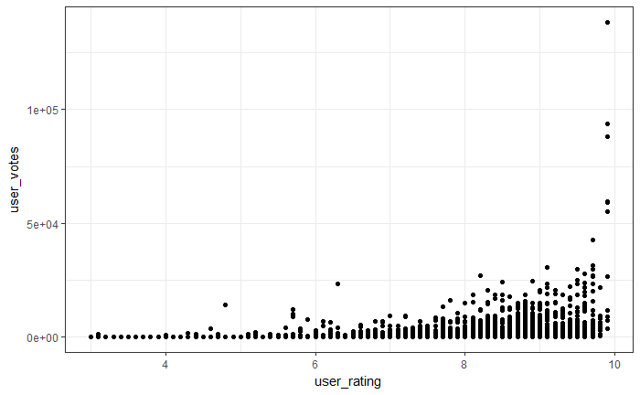

```r
ggplot(series, aes(x=user_rating, y=user_votes)) + geom_point()
```

Como é possível observar, há alguns poucos pontos muito acima do normal em user_votes. Irei limitar o eixo y para 50000 votos. Assim, teremos um gráfico que pode ser melhor analisado.

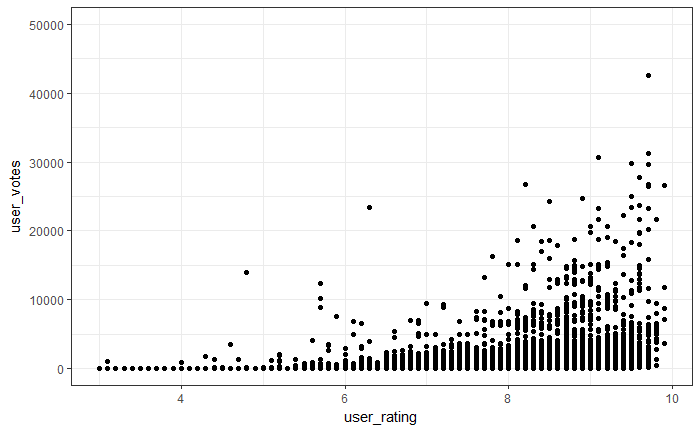

```r
ggplot(series, aes(x=user_rating, y=user_votes)) + geom_point() + coord_cartesian(ylim = c(0, 50000))
```

Podemos ver que a maior parte dos episódios apresenta quantidade de vontantes abaixo de 10000. E não necessariamente é verdade que séries com poucos votos são melhor votadas. É mais fácil de acontecer o contrário, episódios muito votados apresentarem notas melhores. Isso explica porque nenhum dos 3 coeficientes deu valor negativo. Também podemos observar que a correlação é, no máximo, moderada entre as duas variáveis, já que a maioria dos episódios apresenta número de votos parecido e apenas uma pequena parcela ultrapassa esse limiar.

# 2. Com o passar das temporadas a quantidade de votantes tende a cair?

## 2.1. Hipótese

Com o passar das temporadas a quantidade de vontantes tende a cair, pois quem não assitiu a primeira temporada não assistirá a segunda, o que reduz a audiência e consequentemente a quantidade de vontantes.

## 2.2. Análise

Para responder a essa pergunta irei plotar o gráfico de distribuição da quantidade de votos por temporada, e também uma tabela com as médias da quantidade de votos por temporada.

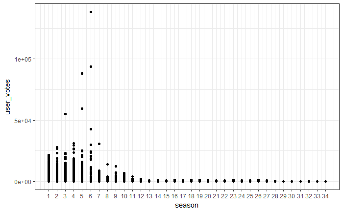

```r
series = series %>% mutate(season = as.integer(season))
series %>%
    ggplot(aes(x = season, y = user_votes)) + geom_point() + scale_x_continuous(breaks=c(1:34), labels=c(1:34))
```

```r
knitr::kable(summarise(series %>% group_by(season), media = mean(user_votes), cvar = (sd(user_votes) / mean(user_votes))))
```

```
| season|     media|      cvar|
|------:|---------:|---------:|
|      1| 642.58926| 2.0860570|
|      2| 587.63795| 2.1319014|
|      3| 622.42752| 2.4878525|
|      4| 660.93738| 2.5989725|
|      5| 757.18380| 3.7798676|
|      6| 831.42646| 5.1638210|
|      7| 652.61894| 1.8748224|
|      8| 609.83211| 1.2980137|
|      9| 648.08651| 1.3433061|
|     10| 581.93214| 1.4306331|
|     11| 369.18118| 1.4044034|
|     12| 323.46684| 1.1894989|
|     13| 158.50163| 1.3197456|
|     14| 144.68699| 1.3790097|
|     15| 148.29167| 1.3953335|
|     16| 165.79310| 1.3882188|
|     17| 179.33333| 1.3071056|
|     18| 174.79070| 1.4915241|
|     19| 186.41304| 1.6404180|
|     20| 332.68750| 1.0153113|
|     21| 299.06000| 0.9861425|
|     22| 286.75000| 0.9587701|
|     23| 312.06122| 1.0830863|
|     24| 244.77551| 0.9649920|
|     25| 268.91837| 0.9790350|
|     26| 260.33333| 0.9908513|
|     27| 213.38776| 0.9904265|
|     28| 138.63830| 0.7830392|
|     29|  44.88462| 0.3907128|
|     30|  65.21429| 0.1094540|
|     31|  78.92857| 0.2284040|
|     32|  69.53333| 0.1896179|
|     33|  65.35714| 0.1755446|
|     34|  60.46154| 0.3099851|
```

É possível notar que não há grande variação nas primeiras 10 temporadas, a média e a distribuição permanecem semelhantes. A partir da temporada 11 há uma grande queda. Isso se dá pelo fato de que existem poucas séries com mais de 10 temporadas, assim a quantidade de séries sendo avaliadas reduz drasticamente. No geral, podemos concluir que nas primeiras temporadas a quantidade de votantes não reduz como o esperado na hipótese. E sobre as temporadas acima da décima podemos concluir pouco pois a amostra é pequena.